# Tidy Tuesday Week 15: U.S. Craft Breweries

# What is Tidy Tuesday?

Tidy Tuesday is a data project hosted every week by the [R for Data Science learning community.](https://github.com/rfordatascience/tidytuesday) Anyone is welcome to participate, and are encouraged to colloborate and share their findings on Twitter with the [R4DS community](https://twitter.com/R4DScommunity).This week we are examining Craft Breweries around the U.S. with data from [this article](https://www.thrillist.com/news/nation/most-craft-breweries-by-state-united-states).

## Read in Data

I read in the two sheets from the excel data, added the full state name from the abbreviation using the built-in nifty state.name and state.abb vectors.

```r
beers <- read_xlsx("/Users/Joe/Documents/Github/tidytuesday/data/week15_beers.xlsx", sheet = 1)
breweries <- read_xlsx("/Users/Joe/Documents/Github/tidytuesday/data/week15_beers.xlsx", sheet = 2)

names(beers)[5] <- "beer_name"
names(breweries)[5] <- "brewery_id"

beers <- beers %>%
  left_join(breweries, by = "brewery_id") %>%
  select(-count.x, -count.y, -id)
rm(breweries)

# Add full state name to df
beers <- beers %>%
  mutate(region = tolower(state.name[match(beers$state, state.abb)]))

# Capitalize state names
beers$region <- gsub("(\\b[a-z]{1})", "\\U\\1" , beers$region, perl=TRUE)
```

## Top 10 Beer Styles

I wanted to create a table that shows the top ten most popular beer styles from all of the breweries that showed the beer name, the number of occurrences, the mean ABV, and the mean IBU.

```r
# Gets the top 10 styles
top_10_styles <- beers %>%
  # Find the top 10 most popular
  group_by(style) %>%
  count() %>%
  arrange(desc(n)) %>%
  ungroup() %>%
  top_n(10) %>%
  # Join the ABV and IBU
  left_join(beers %>%
              group_by(style) %>%
              summarise(Mean_ABV = paste(round(mean(na.omit(abv)) * 100, 2), "%"),
                        Mean_IBU = round(mean(na.omit(ibu)), 2)))


top_10_styles %>%
  kable(caption = "Top 10 Beer Styles from U.S. Craft Breweries (NA values omitted)",
        col.names = c("Beer Style", "Count", "Mean ABV", "Mean IBU"),
        align = c("l","c", "c", "c")) %>%
  kable_styling()
```

Top 10 Beer Styles from U.S. Craft Breweries (NA values omitted)

| Beer Style | Count | Mean ABV | Mean IBU |
| --- | --- | --- | --- |
| American IPA | 424 | 6.45 % | 67.63 |
| American Pale Ale (APA) | 245 | 5.46 % | 44.94 |
| American Amber / Red Ale | 133 | 5.75 % | 36.30 |
| American Blonde Ale | 108 | 4.96 % | 20.98 |
| American Double / Imperial IPA | 105 | 8.74 % | 93.32 |
| American Pale Wheat Ale | 97 | 4.84 % | 20.69 |
| American Brown Ale | 70 | 5.79 % | 29.89 |
| American Porter | 68 | 5.96 % | 31.92 |
| Saison / Farmhouse Ale | 52 | 6.14 % | 28.39 |
| Witbier | 51 | 5.36 % | 16.21 |

# IBU Distributions of the Top 10 Beers

Next, I wanted to see if there are general trends with IBU in the most popular beers, especially because of how popular pale ales are, which are notorious for their hoppiness.

```r
beers_style <- beers %>%
  filter(style %in% top_10_styles$style)

beers_style$style <- fct_rev(factor(beers_style$style, levels = c("American IPA", "American Pale Ale (APA)", "American Amber / Red Ale", "American Blonde Ale", "American Double / Imperial IPA", "American Pale Wheat Ale", "American Brown Ale", "American Porter", "Saison / Farmhouse Ale", "Witbier")))

joyplot <- beers_style %>%
  ggplot(aes(x = ibu, y = style)) +
  geom_density_ridges(fill = "#6093ca") +
  theme_fivethirtyeight() +
  theme(axis.title = element_text(),
        axis.title.y = element_blank(),
        plot.caption = element_text(size = 8),
        plot.title = element_text(hjust = 1,
                                  size = 15)) +
  xlab("IBU") +
  labs(title = "How bitter are the 10 Most Popular Beer Styles?",
       caption = "@Joe_Stoica") +
  scale_x_continuous(breaks = seq(0,150,10))
ggsave(joyplot, filename = "joyplot.png")
```

## ABV vs. IBU Scatterplot

Next I wanted to see the relationship between ABV and IBU.

```r
scatter <- beers %>%
  group_by(style) %>%
  summarise(mean_ABV = mean(na.omit(abv)),
            mean_IBU = mean(na.omit(ibu)),
            n = n()) %>%
  ggplot(aes(mean_ABV, mean_IBU)) +
  geom_point(color = "#ff6961",
             aes(size = n)) +
  geom_text_repel(aes(label = ifelse(n >= 50, style, "")),
                  size = 3.5,
                  box.padding = unit(0.7, "lines")) +
  theme_fivethirtyeight()+
  theme(axis.text = element_text(),
        axis.title = element_text(),
        plot.caption = element_text(size = 8),
        plot.title = element_text(hjust = 0.5),
        legend.position = "top") +
  xlab("Mean ABV") +
  ylab("Mean IBU") +
  labs(title = "ABV vs. IBU",
       caption = "@Joe_Stoica",
       size = "") +
  scale_x_continuous(breaks = seq(0, .1, .02),
                     labels = percent)
ggsave(scatter, filename = "scatter.png")
```

## Bar Chart Remake

```r
top_5 <- beers %>%
  group_by(region) %>%
  summarise(n = length(unique(name))) %>%
  arrange(desc(n)) %>%
  ungroup() %>%
  top_n(5)

top_5$region <- fct_rev(factor(top_5$region, levels = c("Colorado", "California", "Michigan", "Oregon", "Texas" )))

remake <- top_5 %>%
  ggplot(aes(region, n)) +
  geom_bar(stat = "identity",
           fill = "#f48444",
           width = 0.5) +
  # States
  geom_text(aes(label = region),
            size = 6,
            hjust = 1.15,
            vjust = 0.4) +
  # Numbers
  geom_text(aes(label = n),
            size = 6,
            hjust = -.15) +
  coord_flip() +
  theme_fivethirtyeight() +
  theme(axis.ticks.y = element_blank(),
        axis.text.y = element_blank(),
        axis.title = element_blank(),
        plot.title = element_text(hjust = 0.5),
        plot.caption = element_text(size = 8),
        panel.background = element_blank(),
        axis.line.x = element_line(colour = "dark grey",
                                   linetype = 2),
        panel.grid.major = element_blank()) +
  labs(title = "Top Five States With the Most Breweries",
       caption = "@Joe_Stoica")
ggsave(remake, filename = "remake.png")
```

## IBU by Top Five States with Most Breweries

```r
boxplot <- beers %>%
  filter(region %in% c("Colorado", "California",
                       "Michigan", "Oregon", "Texas" )) %>%
  ggplot(aes(x = region, y = ibu)) +
  geom_boxplot(outlier.color = "red") +
  theme_fivethirtyeight() +
  theme(axis.title = element_text(),
        axis.title.x = element_blank(),
        plot.caption = element_text(size = 8),
        plot.title = element_text(hjust = 0.5,
                                  size = 15)) +
  ylab("IBU") +
  labs(title = "IBU Distribution in the Five States with the Most Breweries",
       caption = "@Joe_Stoica")
ggsave(boxplot, filename = "boxplot.png")
```

## Stuff I didn’t really like the direction of where it was heading

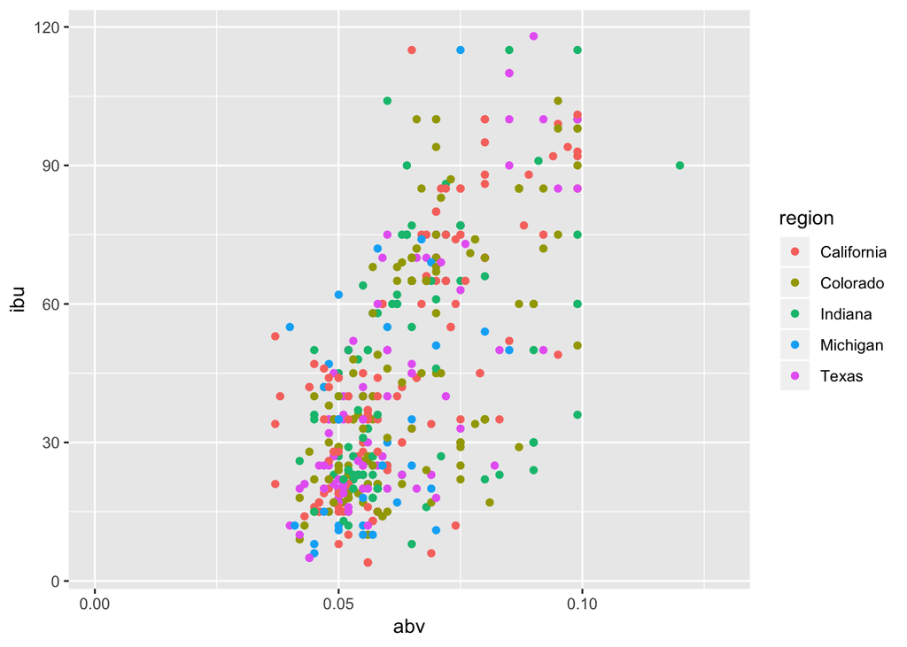

```r
top_5 <- beers %>%
  group_by(region) %>%
  count() %>%
  arrange(desc(n)) %>%
  ungroup() %>%
  top_n(5)

beers %>%
  filter(region %in% top_5$region) %>%
  ggplot(aes(abv, ibu)) +
  geom_point(aes(color = region))
```

No distinct clusterings, which is what I expected.

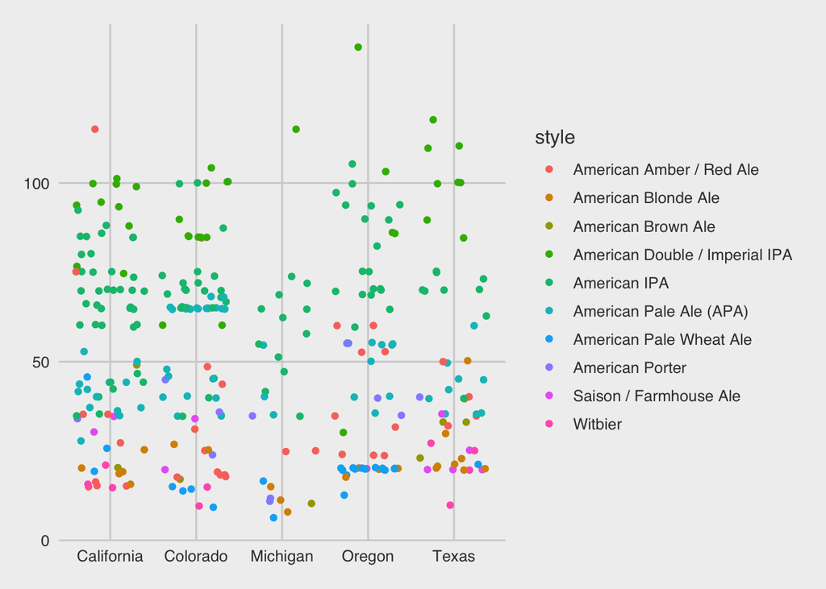

```r
beers %>%
  filter(region %in% c("Colorado", "California", "Michigan", "Oregon", "Texas"),
         style %in% top_10_styles$style) %>%
  ggplot(aes(x = region, y = ibu)) +
  geom_jitter(aes(color = style)) +
  theme_fivethirtyeight() +
  theme(legend.position = "right",
        legend.direction = "vertical")
```